# R Midterm take home portion

Harsh Tandon W1580393

```r
dir()
```

```
##  [1] "bitly.json"
##  [2] "htandon_midtermTakeHome_fall2019.html"
##  [3] "htandon_midtermTakeHome_fall2019.rmd"
##  [4] "midterm.html"
##  [5] "midterm.nb.html"
##  [6] "midterm.R"
##  [7] "midterm_files"
##  [8] "New Text Document.txt"
##  [9] "NewCsv.csv"
## [10] "TakeHomeMidterm.pdf"
## [11] "titanic.csv"
```

```r
setwd("D:/1st Qtr Study Material/R/Midterm")  #set working directory
#import all used libraries
library(dplyr)
```

```r
library(ggplot2)
library(jsonlite)
```

# Part 1

### 1. Load titanic.csv dataset

```r
data = read.csv("D:/1st Qtr Study Material/R/Midterm/titanic.csv")
```

### 2. Get rid of columns “Name”, “Ticket”, “PassengerId”, “Cabin”

```r
colToRemove = c(which(colnames(data)=="Name"),
                which(colnames(data)=="Ticket"),
                which(colnames(data)=="PassengerId"),
                which(colnames(data)=="Cabin"))

data = data[-colToRemove]
```

### 3. Replace the ‘Sex column with a binary column for whether the passenger is ’Male’

```r
levels(data$Sex) = c(0,1)
levels(data$Sex)
```

```
## [1] "0" "1"
```

```r
colIndexOfSex = which(colnames(data)=="Sex")
names(data)[colIndexOfSex] = "isMale"
data
```

| Survived | Pclass | isMale | Age | SibSp | Parch | Fare | Embarked |
| --- | --- | --- | --- | --- | --- | --- | --- |
| 0 | 3 | 1 | 22.00 | 1 | 0 | 7.2500 | S |
| 1 | 1 | 0 | 38.00 | 1 | 0 | 71.2833 | C |
| 1 | 3 | 0 | 26.00 | 0 | 0 | 7.9250 | S |
| 1 | 1 | 0 | 35.00 | 1 | 0 | 53.1000 | S |
| 0 | 3 | 1 | 35.00 | 0 | 0 | 8.0500 | S |
| 0 | 3 | 1 | NA | 0 | 0 | 8.4583 | Q |
| 0 | 1 | 1 | 54.00 | 0 | 0 | 51.8625 | S |
| 0 | 3 | 1 | 2.00 | 3 | 1 | 21.0750 | S |
| 1 | 3 | 0 | 27.00 | 0 | 2 | 11.1333 | S |
| 1 | 2 | 0 | 14.00 | 1 | 0 | 30.0708 | C |

[output cut: 881 more lines]

### 4. Show how many NA’s are in each column

```r
colSums(is.na(data))
```

```
## Survived   Pclass   isMale      Age    SibSp    Parch     Fare Embarked
##        0        0        0      177        0        0        0        0
```

### 5. Which Column has the most NA’s? How many does it have?

We see from Q4 that “Age” has most number of NA’s. It has 177 NA values

### 6. Create a bar chart to show NA counts by column

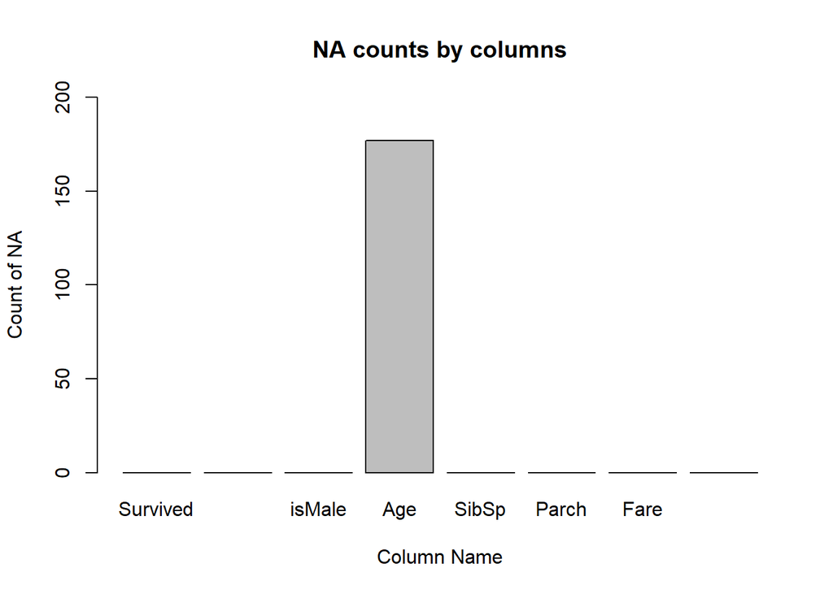

```r
NAcount = (colSums(is.na(data)))
barplot(NAcount, xlab = "Column Name", ylab = "Count of NA", ylim = c(0,200), main = "NA counts by columns")
```

### 7. Plot the distribution of ages for each gender.

#### Is the average (mean) age of Males higher?

From the density plot, we see that Average age of Males is higher than Females.

```r
mu <- data %>%
  group_by(isMale) %>%
  summarise(grp_mean = mean(Age, na.rm = TRUE))
mu
```

| isMale | grp_mean |
| --- | --- |
| 0 | 27.91571 |
| 1 | 30.72664 |

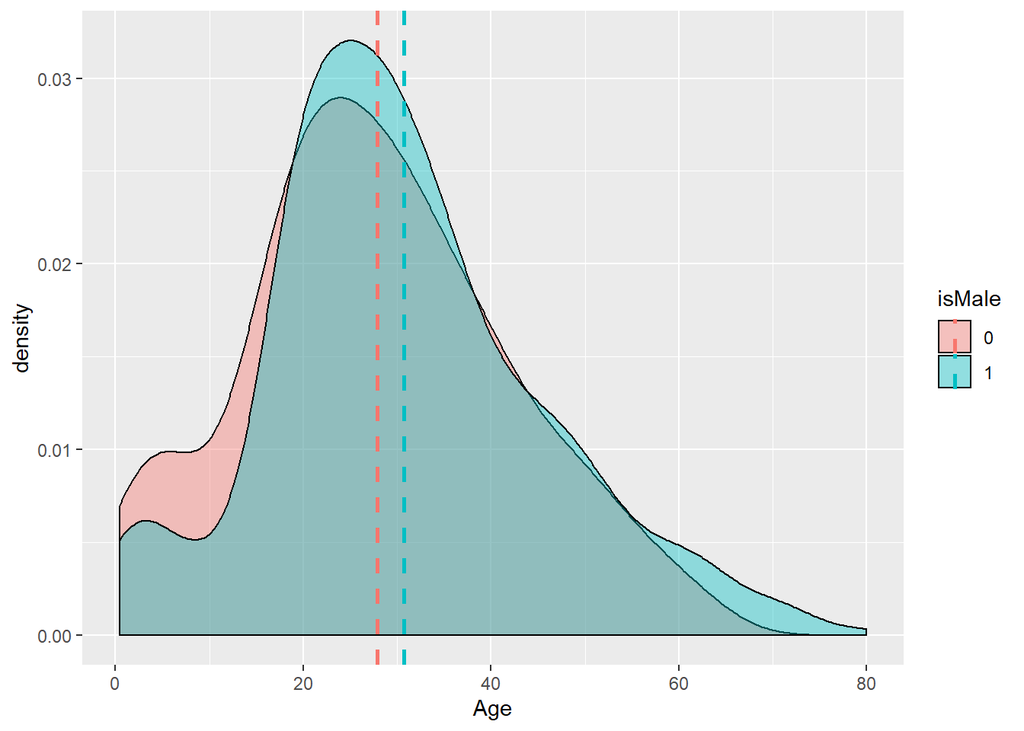

```r
ggplot(data = data, aes(x = Age)) +
  geom_density(aes(fill = isMale), alpha = 0.4) +
  geom_vline(aes(xintercept = grp_mean, color = isMale),
             data = mu, linetype = "dashed",size = 1)
```

#### Is the median higher?

We see that Median value of Age for Males is higher than Females.

```r
median <- data %>%
  group_by(isMale) %>%
  summarise(grp_median = median(Age, na.rm = TRUE))
median
```

| isMale | grp_median |
| --- | --- |
| 0 | 27 |
| 1 | 29 |

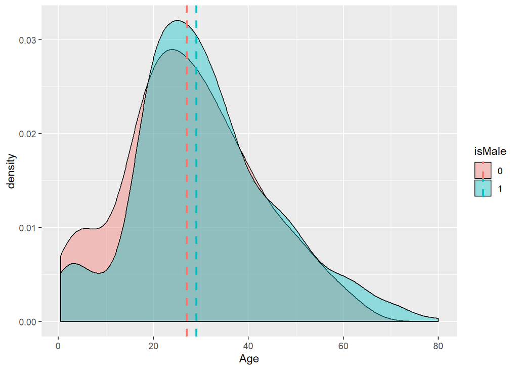

```r
ggplot(data = data, aes(x = Age)) +
  geom_density(aes(fill = isMale), alpha = 0.4) +
  geom_vline(aes(xintercept = grp_median, color = isMale),
             data = median, linetype = "dashed",size = 1)
```

### 8. Which port of origin (embarked column) had the highest average fare? Show/plot your results.

```r
avg_Fare <- data %>%
  group_by(Embarked) %>%
  summarise(grp_mean = mean(Fare, na.rm = TRUE))
avg_Fare
```

| Embarked | grp_mean |
| --- | --- |
|  | 80.00000 |
| C | 59.95414 |
| Q | 13.27603 |
| S | 27.07981 |

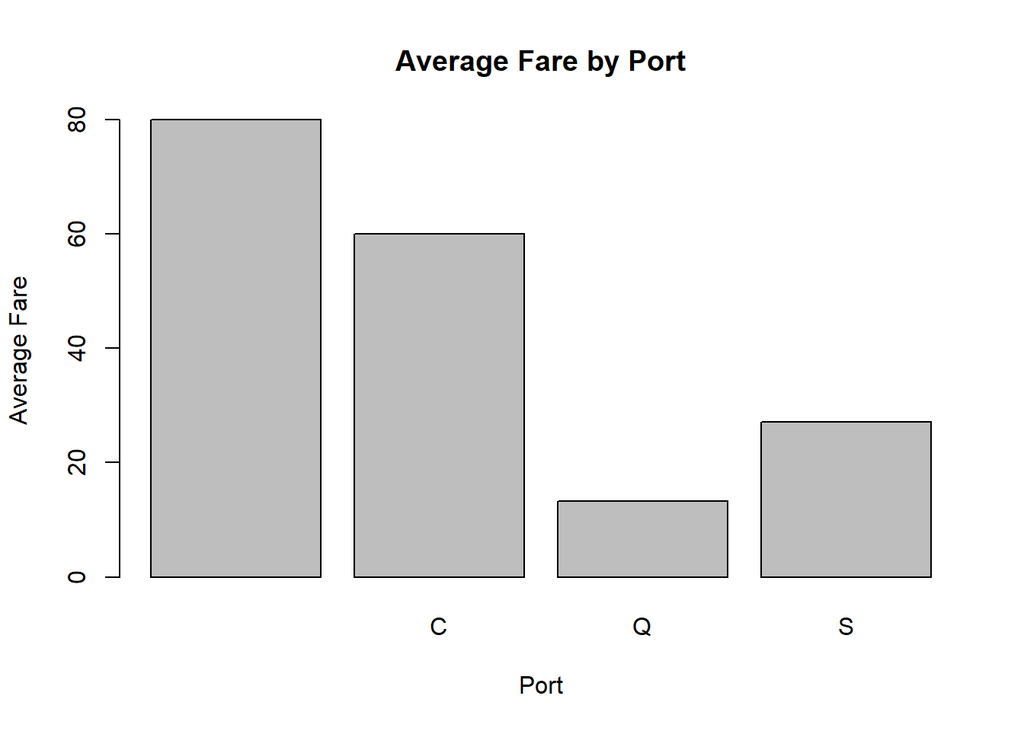

```r
barplot(avg_Fare$grp_mean, names.arg = avg_Fare$Embarked, main = "Average Fare by Port", ylab = "Average Fare", xlab = "Port")
```

```r
avg_Fare <- data %>%
  group_by(isMale) %>%
  summarise(grp_mean = mean(Fare, na.rm = TRUE))
avg_Fare
```

| isMale | grp_mean |
| --- | --- |
| 0 | 44.47982 |
| 1 | 25.52389 |

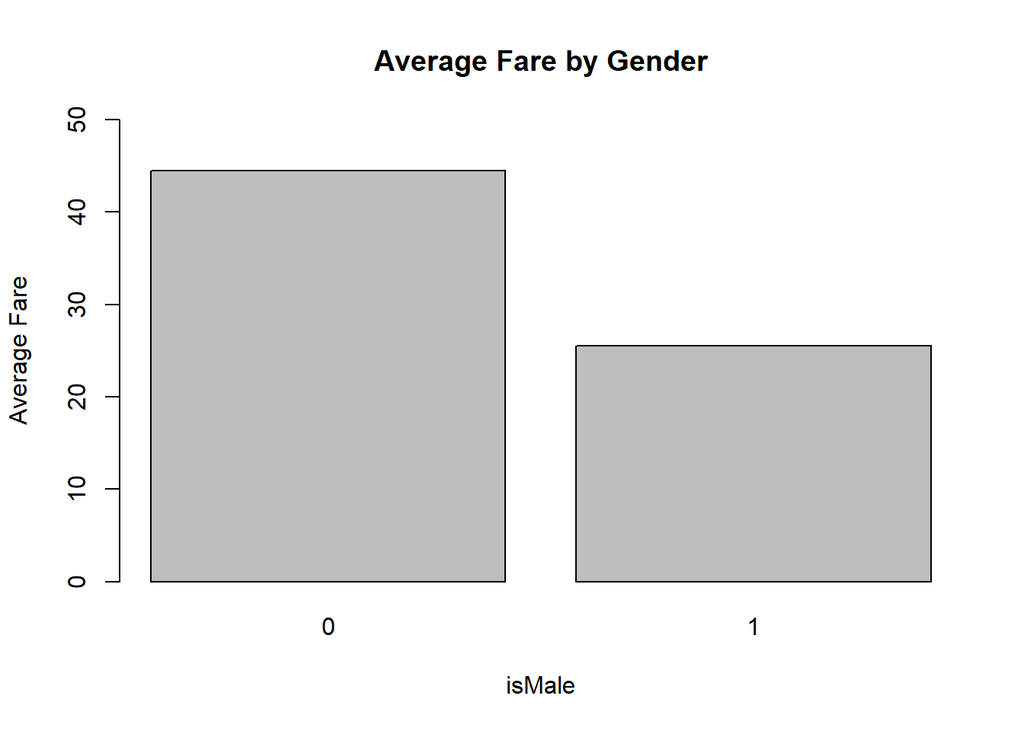

```r
barplot(avg_Fare$grp_mean, names.arg = avg_Fare$isMale, main = "Average Fare by Gender", ylab = "Average Fare", xlab = "isMale", ylim = c(0,50))
```

# Part 2

### 1. Load the bitly data from data.gov as a data frame.

```r
data2 = stream_in(url("https://raw.githubusercontent.com/denisvrdoljak/MSIS2506_Fall2019/master/TakeHomeMidterm/bitly_usagov_example.txt"))
```

```
## opening url input connection.
```

```
##
 Found 500 records...
 Found 1000 records...
 Found 1500 records...
 Found 2000 records...
 Found 2500 records...
 Found 3000 records...
 Found 3500 records...
 Found 3560 records...
 Imported 3560 records. Simplifying...
```

```
## closing url input connection.
```

### 2. How many records are there?

```r
print(nrow(data2))
```

```
## [1] 3560
```

### 3. In the City column (‘cy’), how many are NA?

```r
sum(is.na(data2$cy))
```

```
## [1] 641
```

### 4. How many countries are present in this data?

#### Which country (‘c’ column) has the most records? How many does it have?

From the results we see that, US has the most records. It has 2305 records!

```r
data2$c = as.factor(data2$c)
levels(data2$c)
```

```
##  [1] "AE" "AR" "AT" "AU" "BE" "BG" "BO" "BR" "CA" "CH" "CL" "CN" "CO" "CR"
## [15] "CY" "CZ" "DE" "DK" "DO" "EC" "EG" "ES" "FI" "FR" "GB" "GR" "HK" "HN"
## [29] "HU" "ID" "IE" "IL" "IN" "IT" "JO" "JP" "KN" "KR" "LB" "LT" "LV" "MA"
## [43] "MK" "MT" "MX" "MY" "NI" "NL" "NO" "NZ" "PE" "PH" "PK" "PL" "PR" "PT"
## [57] "RO" "RS" "RU" "SA" "SE" "SI" "SK" "TH" "TR" "UA" "US" "UY" "VE" "ZA"
## [71] "ZM"
```

```r
summary(data2$c)
```

```
##   AE   AR   AT   AU   BE   BG   BO   BR   CA   CH   CL   CN   CO   CR   CY
##    4    3    6    7    4    1    1   35   60    4    6    3    3    1    1
##   CZ   DE   DK   DO   EC   EG   ES   FI   FR   GB   GR   HK   HN   HU   ID
##   10   28    5    1    2    3   37   10   14   74    6   10    1    5    4
##   IE   IL   IN   IT   JO   JP   KN   KR   LB   LT   LV   MA   MK   MT   MX
##    3    3    9   27    2   37    1    5    4    2    2    1    1    2   19
##   MY   NI   NL   NO   NZ   PE   PH   PK   PL   PR   PT   RO   RS   RU   SA
##    4    3   22   10   11    1    1    3   16   10    8    4    2   13    1
##   SE   SI   SK   TH   TR   UA   US   UY   VE   ZA   ZM NA's
##   14    1    3    6    9    1 2305    1    1    1    1  641
```

### 5. How many records are from Russia?

There are 13 records from Russia.

```r
count(data2,  data2$c == "RU")
```

| data2$c == "RU" | n |
| --- | --- |
| FALSE | 2906 |
| TRUE | 13 |
| NA | 641 |

### 6. How many records do NOT list USA?

There are 614 records that do not list USA.

```r
count(data2, data2$c != "US")
```

| data2$c != "US" | n |
| --- | --- |
| FALSE | 2305 |
| TRUE | 614 |
| NA | 641 |

### 7. How many records have ‘America’ in the timezone, but Country not in US?

There are 143 records having “America” in timezone, but country not equal to US.

```r
hasAmerica = dplyr::filter(data2, grepl("America", tz))
count(hasAmerica, c != "US")
```

| c != "US" | n |
| --- | --- |
| FALSE | 2269 |
| TRUE | 143 |

### 8. How many records point to cia.gov?

```r
cia = dplyr::filter(data2, grepl("cia.gov", u))
length(cia)
```

```
## [1] 18
```

### 9. Fill empty records with “UNKNOWN” and NA’s with “MISSING”. Create a new csv.

```r
sum(is.na(data2))
```

```
## [1] 10616
```

```r
data2[is.na(data2)] = "MISSING"
data2[data2 == ""] = "UNKNOWN"
sum(is.na(data2))
```

```
## [1] 641
```

```r
data3 = apply(data2,2,as.character)

write.table(data3, file = "NewCsv.csv", sep = ",", col.names = TRUE, row.names = FALSE)
```

### 10. Show the top 10 timezones (‘tz’ column) in a bar chart

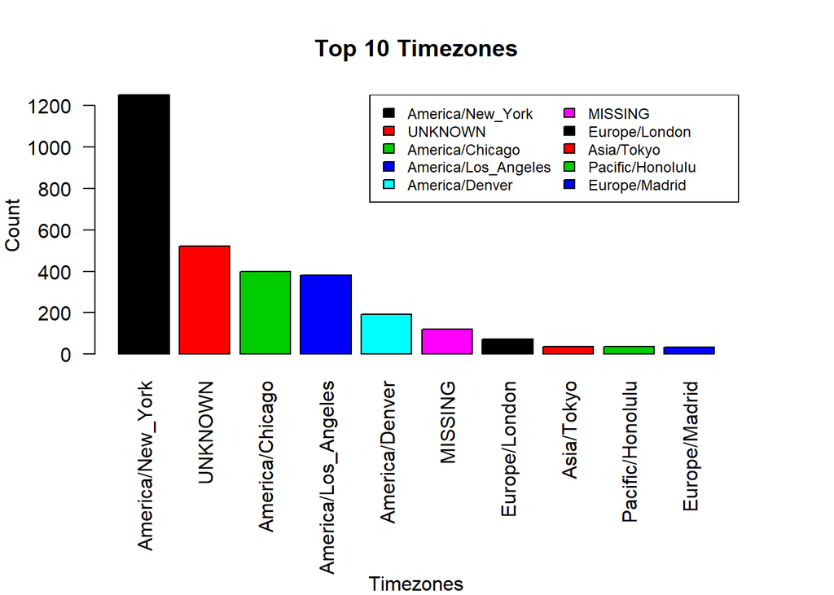

```r
data2$tz = as.factor(data2$tz)
timezones = summary(data2$tz)
timezones = sort(timezones, decreasing = TRUE)
top10 = timezones[1:10]

par(mar=c(10,4,4,4))
barplot(top10, las = 2, main = "Top 10 Timezones", ylab = "Count", col = 1:6)
legend("topright", cex = 0.75, ncol = 2, legend = names(top10), fill = 1:6)
title(xlab="Timezones" ,mgp=c(9,1,0))
```